# Assignment 2

xw-zeng

2022-10-20

# README

Install and load the packages.

```r
##install.packages('DT')
##install.packages('ggplot2')
##install.packages('dplyr')
##install.packages('patchwork')
library(DT) ##For table preview.
library(ggplot2) ##For visualization.
library(dplyr) ##For set arithmetic.
library(patchwork) ##For plot composing.
```

List of optimization functions.

- `Local_Search`: Local Search method with Deepest Ascent or Random Ascent.
- `Tabu_Algorithm`: Tabu Algorithm with four attributes defined by myself.
- `Simulated_Annealing_C`: Simulated Annealing for combinatorial optimization.
- `Simulated_Annealing_N`: Simulated Annealing for numerical optimization.
- `Genetic_Algorithm`: Genetic Algorithm with order crossover or edge-recombination crossover strategy.

# 3.1

## (a)

Load and preview data `baseball.dat`.

```r
data <- read.table('baseball.dat', header = TRUE)
DT::datatable(data)
```

|  | salary | average | obp | runs | hits | doubles | triples | homeruns | rbis | walks | sos | sbs | errors | freeagent | arbitration | runsperso | hitsperso | hrsperso | rbisperso | walksperso | obppererror | runspererror | hitspererror | hrspererror | soserrors | sbsobp | sbsruns | sbshits |
| --- | --- | --- | --- | --- | --- | --- | --- | --- | --- | --- | --- | --- | --- | --- | --- | --- | --- | --- | --- | --- | --- | --- | --- | --- | --- | --- | --- | --- |
| 1 | 3300 | 0.272 | 0.302 | 69 | 153 | 21 | 4 | 31 | 104 | 22 | 80 | 4 | 4 | 1 | 0 | 0.8625 | 1.9125 | 0.3875 | 1.3 | 0.275 | 0.0755 | 17.25 | 38.25 | 7.75 | 320 | 1.208 | 276 | 612 |
| 2 | 2600 | 0.269 | 0.335 | 58 | 111 | 17 | 2 | 18 | 66 | 39 | 69 | 0 | 4 | 1 | 0 | 0.8406 | 1.6087 | 0.2609 | 0.9565 | 0.5652 | 0.0838 | 14.5 | 27.75 | 4.5 | 276 | 0 | 0 | 0 |
| 3 | 2500 | 0.249 | 0.337 | 54 | 115 | 15 | 1 | 17 | 73 | 63 | 116 | 6 | 6 | 1 | 0 | 0.4655 | 0.9914 | 0.1466 | 0.6293 | 0.5431 | 0.0562 | 9 | 19.1667 | 2.8333 | 696 | 2.022 | 324 | 690 |
| 4 | 2475 | 0.26 | 0.292 | 59 | 128 | 22 | 7 | 12 | 50 | 23 | 64 | 21 | 22 | 0 | 1 | 0.9219 | 2 | 0.1875 | 0.7812 | 0.3594 | 0.0133 | 2.6818 | 5.8182 | 0.5455 | 1408 | 6.132 | 1239 | 2688 |
| 5 | 2313 | 0.273 | 0.346 | 87 | 169 | 28 | 5 | 8 | 58 | 70 | 53 | 3 | 9 | 0 | 1 | 1.6415 | 3.1887 | 0.1509 | 1.0943 | 1.3208 | 0.0384 | 9.6667 | 18.7778 | 0.8889 | 477 | 1.038 | 261 | 507 |
| 6 | 2175 | 0.291 | 0.379 | 104 | 170 | 32 | 2 | 26 | 100 | 87 | 89 | 22 | 5 | 1 | 0 | 1.1685 | 1.9101 | 0.2921 | 1.1236 | 0.9775 | 0.0758 | 20.8 | 34 | 5.2 | 445 | 8.338 | 2288 | 3740 |
| 7 | 600 | 0.258 | 0.37 | 34 | 86 | 14 | 1 | 14 | 38 | 15 | 45 | 0 | 11 | 1 | 0 | 0.7556 | 1.9111 | 0.3111 | 0.8444 | 0.3333 | 0.0336 | 3.0909 | 7.8182 | 1.2727 | 495 | 0 | 0 | 0 |
| 8 | 460 | 0.228 | 0.279 | 16 | 38 | 7 | 2 | 3 | 21 | 11 | 32 | 2 | 4 | 0 | 0 | 0.5 | 1.1875 | 0.0938 | 0.6562 | 0.3438 | 0.0698 | 4 | 9.5 | 0.75 | 128 | 0.558 | 32 | 76 |
| 9 | 240 | 0.25 | 0.327 | 40 | 61 | 11 | 0 | 1 | 18 | 24 | 26 | 14 | 3 | 0 | 0 | 1.5385 | 2.3462 | 0.0385 | 0.6923 | 0.9231 | 0.109 | 13.3333 | 20.3333 | 0.3333 | 78 | 4.578 | 560 | 854 |
| 10 | 200 | 0.203 | 0.24 | 39 | 64 | 10 | 1 | 10 | 33 | 14 | 96 | 13 | 7 | 0 | 0 | 0.4062 | 0.6667 | 0.1042 | 0.3438 | 0.1458 | 0.0343 | 5.5714 | 9.1429 | 1.4286 | 672 | 3.12 | 507 | 832 |

[output cut: 327 more lines]

Modify variable types.

```r
data$freeagent <- factor(data$freeagent)
data$arbitration <- factor(data$arbitration)
```

Generate the dependent variable `logsalary` and covariates `data_sub`.

```r
logsalary <- log(data$salary)
data_sub <- data[, -1]
```

Define the `Local Search` function, which enables us to choose Steepest Ascent or Random Ascent by setting the logical parameter `steepest`.

- `y`: dependent variable.
- `vars`: a data frame of all covariates.
- `randnum`: number of random starts.
- `itertime`: iteration times for each random start.
- `steepest`: a logical indicating whether Steepest Ascent or Random Ascent is applied.

```r
Local_Search <- function(y, vars, randnum, itertime, steepest = FALSE){

  ###INITIAL VALUES###
  var_num <- ncol(vars)
  start <- matrix(NA, randnum, var_num)
  for(i in 1:randnum){start[i, ] <- rbinom(var_num, 1, 0.5)}
  aic <- matrix(NA, randnum, itertime)
  results <- matrix(NA, randnum, var_num)

  ###FUNCTIONS###
  generate_N1 <- function(x){
    out <- matrix(NA, var_num, var_num)
    order <- sample(1:var_num, var_num)
    for (i in 1:var_num){
      x_temp <- x
      x_temp[order[i]] <- !x[order[i]]
      out[i, ] <- x_temp}
    return (out)
  }
  generate_AIC <- function(x){
    vars_run <- vars[, x == 1]
    fit <- lm(y ~ ., vars_run)
        return (extractAIC(fit)[2])
  }

  ###MAIN###
  ##ITERATE EACH RANDOM START
  for (i in 1:randnum){
    x <- start[i, ]

    for (j in 1:itertime){
          aic_local <- generate_AIC(x)
          n1 <- generate_N1(x)
          flag <- FALSE

          ##MOVE IN A LOCAL NEIGHBORHOOD
          for (k in 1:var_num){
            x_run <- n1[k, ]
            aic_run <- generate_AIC(x_run)
            ##RANDOM ASCENT
            if (aic_run < aic_local){
              flag <- TRUE
              aic_local <- aic_run
              x <- x_run
              ##STEEPEST ASCENT
              if (steepest == FALSE){break}}
          }

          ##IF THE BEST COMBINATION DOESN'T CHANGE, BREAK
          if (flag == TRUE){aic[i, j] <- aic_local}
          else {break}
    }

    results[i, ] <- x
    if (is.na(aic[i, j])){aic[i, j:itertime] <- aic[i, j - 1]}
  }

  ###OUTPUT###
  structure(list(method = paste(ifelse(steepest, 'Steepest Ascent', 'Random Ascent'), 'Local Search'),
                 start = start,
                 x_best = results,
                 aic_best = aic[, itertime],
                 aic = aic,
                 rand_time = randnum,
                 iter_time = itertime,
                 graph = ggplot() + geom_point(mapping = aes(x = 1:(randnum * itertime), y = c(t(aic)))) + coord_cartesian(ylim = c(-420, -360)) + labs(title = paste(ifelse(steepest, 'Steepest Ascent', 'Random Ascent'), 'Local Search'), x = 'Iteration', y = 'AIC') + theme_light()))
}
```

Compute results.

```r
##Random Ascent
set.seed(2023)
Local_Search(logsalary, data_sub, 10, 15)
```

```
## $method
## [1] "Random Ascent Local Search"
##
## $start
##       [,1] [,2] [,3] [,4] [,5] [,6] [,7] [,8] [,9] [,10] [,11] [,12] [,13]
##  [1,]    0    0    0    0    0    0    0    1    0     0     1     0     0
##  [2,]    0    0    0    1    1    1    0    1    1     1     1     1     1
##  [3,]    0    1    1    1    1    1    0    0    1     0     0     1     0
##  [4,]    1    1    1    1    0    0    0    1    0     1     0     1     1
##  [5,]    1    0    1    1    0    1    0    1    1     1     1     0     1
##  [6,]    1    1    0    1    1    0    0    0    0     0     0     0     0
##  [7,]    1    1    0    1    1    1    1    0    1     1     1     0     0
##  [8,]    0    1    1    0    0    0    0    0    0     0     0     1     1
##  [9,]    0    0    1    0    1    1    1    1    1     0     0     0     1
## [10,]    0    1    0    1    1    0    0    1    0     0     1     0     1
```

[output cut: 104 more lines]

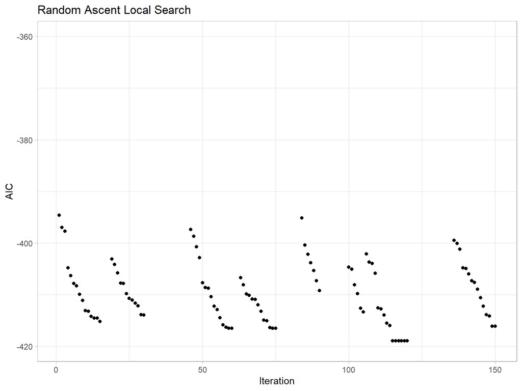

```r
##Steepest Ascent
set.seed(520)
Local_Search(logsalary, data_sub, 10, 15, TRUE)
```

```
## $method
## [1] "Steepest Ascent Local Search"
##
## $start
##       [,1] [,2] [,3] [,4] [,5] [,6] [,7] [,8] [,9] [,10] [,11] [,12] [,13]
##  [1,]    0    0    0    0    0    1    1    0    0     0     1     0     0
##  [2,]    1    0    0    1    0    1    0    0    0     1     1     1     0
##  [3,]    1    0    1    0    0    0    0    0    0     0     0     1     1
##  [4,]    0    0    0    0    1    1    1    0    1     1     0     0     0
##  [5,]    1    0    1    0    1    0    1    1    0     1     1     0     1
##  [6,]    0    1    0    0    1    0    1    1    1     0     1     1     1
##  [7,]    0    1    1    1    1    1    0    1    1     0     1     1     1
##  [8,]    1    0    1    1    0    0    0    1    1     0     0     0     1
##  [9,]    1    1    0    0    0    1    0    1    0     0     0     0     0
## [10,]    1    0    0    0    0    0    0    1    1     0     0     0     1
```

[output cut: 104 more lines]

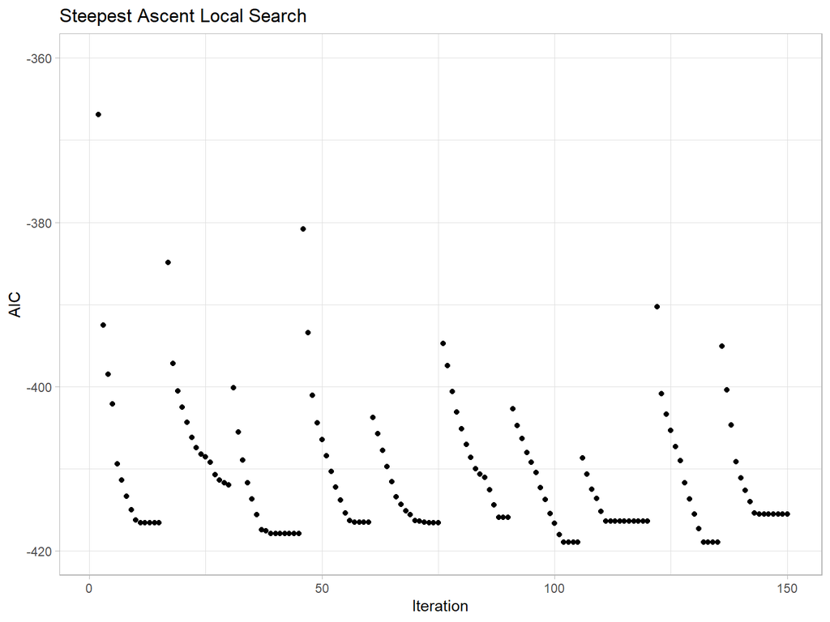

If iterated for the same times, the convergence of Steepest Ascent is always better than Random Ascent at the cost of computing speed. Besides, it turns out that Local Search algorithm frequently converge to local optimal that are not globally competitive. Therefore, 10 random starting values are generated and run in the algorithm to overcome this problem.

# 3.2

## (a)

Define the `Tabu Algorithm` function.

- `y`: dependent variable.
- `vars`: a data frame of all covariates.
- `term`: length of term for tabu moves.
- `itertime`: iteration times.
- `A4`: a logical indicating whether Attribute 4 is applied (added for question (b)).
- `A4_value`: a parameter in Attribute 4.

**Four attributes** are defined in the following algorithm.

- `Attribute 1`: a predictor is added or deleted from the model.
- `Attribute 2`: exchange the absent variable for the variable present in the model.
- `Attribute 3`: value of change in AIC.
- `Attribute 4`: value of change in AIC exceeds `A4_value`.

```r
Tabu_Algorithm <- function(y, vars, term, itertime, A4 = FALSE, A4_value = 1){

  ###FUNCTIONS###
  ##Attribute 1
  Attribute_1 <- function(x){
    out <- matrix(NA, var_num, var_num)
    for (i in 1:var_num){
      x_temp <- x
      x_temp[i] <- !x[i]
      out[i, ] <- x_temp}
    return (out)
  }
  ##Attribute 2
  Attribute_2 <- function(x){
    idx_absent <- which(x == 0)
    idx_present <- which(x == 1)
    out <- matrix(NA, length(idx_absent) * length(idx_present), var_num)
    idx <- 1
    df_idx <- data.frame('index' = 1:(length(idx_absent) * length(idx_present)), 'absent' = NA, 'present' = NA)
    for (i in idx_absent){
      for (j in idx_present){
        x_temp <- x
        x_temp[i] <- !x[i]; x_temp[j] <- !x[j]
        out[idx, ] <- x_temp
        df_idx$absent[idx] <- i; df_idx$present[idx] <- j
        idx <- idx + 1}}
    structure(list(out = out, df = df_idx))
  }
  generate_AIC <- function(x){
    vars_run <- vars[, x == 1]
    fit <- lm(y ~ ., vars_run)
    fit_full <- lm(y ~ ., vars)
    return (extractAIC(fit)[2])
  }

  ###INITIAL VALUES###
  var_num <- ncol(vars)
  x <- rbinom(var_num, 1, 0.5)
  aic <- generate_AIC(x)
  aic_list <- aic
  ##ATTRIBUTE 1
  tabu_list1 <- rep(0, var_num)
  ##ATTRIBUTE 2
  tabu_list2 <- matrix(0, var_num, var_num)
  ##ATTRIBUTE 3
  tabu_list3 <- data.frame('change' = NA, 'term' = itertime + 1)
  ##ATTRIBUTE 4
  tabu_list4 <- 0

  ###MAIN###
  for (i in 1:itertime){
    aic_best <- min(aic_list)
    ##ATTRIBUTE 1
    n1 <- Attribute_1(x); aic_current1 <- c()
    for (j in 1:nrow(n1)){
          x_run <- n1[j, ]
          aic_run <- generate_AIC(x_run)
      aic_current1 <- c(aic_current1, aic_run)
    }
    ##ATTRIBUTE 2
    r2 <- Attribute_2(x); n2 <- r2[['out']]; aic_current2 <- c()
    for (j in 1:nrow(n2)){
          x_run <- n2[j, ]
          aic_run <- generate_AIC(x_run)
      aic_current2 <- c(aic_current2, aic_run)
    }
    aic_current <- c(aic_current1, aic_current2)
    ##WHETHER NEW MODEL SHOULD BE TAKEN
    better <- FALSE
    for (j in 1:length(aic_current)){
      aic_run <- aic_current[order(aic_current)][j]
      idx <- which(aic_current == aic_run)[1]
      if (idx > nrow(n1)){
        flag <- 2
        idx <- idx - nrow(n1)
        x_current <- n2[idx, ]
        idx1 <- r2[['df']]$absent[which(r2[['df']]$index == idx)]
        idx2 <- r2[['df']]$present[which(r2[['df']]$index == idx)]
      }
      else {flag <- 1; x_current <- n1[idx, ]}
      aic_change <- aic_run - aic
      ##NOT IN TABU LIST
      if ((((flag == 1 & tabu_list1[idx] == 0) |
            (flag == 2 & tabu_list2[idx1, idx2] == 0)) &
           aic_change %in% tabu_list3$change == FALSE &
           (tabu_list4 == 0 | abs(aic_change) < A4_value)) |
          ##ASPIRATION: IN TABU LIST, BEST SEEN OVERALL
          (aic_run < aic_best)){
        better <- TRUE
        x <- x_current
        aic <- aic_run
        if (aic < aic_best){x_best <- x; aic_best <- aic}
        aic_list <- c(aic_list, aic)
        break
      }
    }

    ##NO BETTER MODEL → BREAK
    if (better == FALSE){break}

    ##DECREMENT TABU TERMS
    ##ATTRIBUTE 1
    for (k in 1:length(tabu_list1)){
      if (tabu_list1[k] != 0){tabu_list1[k] <- tabu_list1[k] - 1}}
    ##ATTRIBUTE 2
    for (k in 1:length(tabu_list2)){
      if (tabu_list2[k] != 0){tabu_list2[k] <- tabu_list2[k] - 1}}
    ##ATTRIBUTE 3
    idx_remove <- c()
    for (k in 1:nrow(tabu_list3)){
      if (tabu_list3$term[k] > 1){
        tabu_list3$term[k] <- tabu_list3$term[k] - 1}
      else {idx_remove <- c(idx_remove, k)}}
    if (length(idx_remove) != 0){tabu_list3 <- tabu_list3[- idx_remove, ]}
    ##ATTRIBUTE 4
    if (tabu_list4 != 0){tabu_list4 <- tabu_list4 - 1}

    ##UPDATE TABU LIST
    ##ATTRIBUTE 1
    if (flag == 1){tabu_list1[idx] <- term}
    ##ATTRIBUTE 2
    else if (flag == 2){tabu_list2[idx1, idx2] <- term; tabu_list2[idx2, idx1] <- term}
    ##ATTRIBUTE 3
    tabu_list3 <- rbind(tabu_list3, data.frame('change' = - aic_change, 'term' = term))
    ##ATTRIBUTE 4
    if (A4 ==TRUE & abs(aic_change) > A4_value){tabu_list4 <- term}
  }

  ###OUTPUT###
  structure(list(method = 'Tabu Algorithm',
                 x_best = x_best,
                 aic_best = min(aic_list),
                 aic = aic_list[-1],
                 tabu_term = term,
                 iter_time = i,
                 graph = ggplot() + geom_line(mapping = aes(x = 1:i, y = aic_list[-1])) + coord_cartesian(ylim = c(-420, -360)) + labs(title = 'Tabu Algorithm', x = 'Iteration', y = 'AIC') + theme_light()))
}
```

Compute results. According to the following searching curve, 5 is a suitable tabu term because the algorithm attains the global optimal.

```r
set.seed(1314)
Tabu_Algorithm(logsalary, data_sub, 5, 50)
```

```
## $method
## [1] "Tabu Algorithm"
##
## $x_best
##  [1] 0 1 1 0 0 1 0 1 0 1 0 0 1 1 1 1 0 0 0 0 0 0 0 1 1 1 0
##
## $aic_best
## [1] -418.9472
##
## $aic
##  [1] -217.0905 -396.0194 -405.3545 -411.0308 -415.3757 -416.1567 -416.1465
##  [8] -416.6030 -416.5411 -416.6119 -416.5543 -416.5411 -416.4249 -416.3035
## [15] -416.3702 -416.4249 -416.2547 -416.3702 -416.6030 -416.2717 -416.6119
## [22] -416.5543 -416.5411 -416.6119 -416.4101 -416.5069 -416.5157 -417.2714
## [29] -416.9396 -418.0818 -418.9421 -418.9472 -418.0125 -417.8494 -418.9472
## [36] -417.7992 -418.9421 -418.9472 -418.0125 -417.8494 -418.9472 -418.0000
## [43] -416.9628 -418.9472 -418.9421 -418.4511 -418.1540 -418.9421 -418.0818
## [50] -416.9571
##
## $tabu_term
## [1] 5
##
## $iter_time
## [1] 50
##
## $graph
```

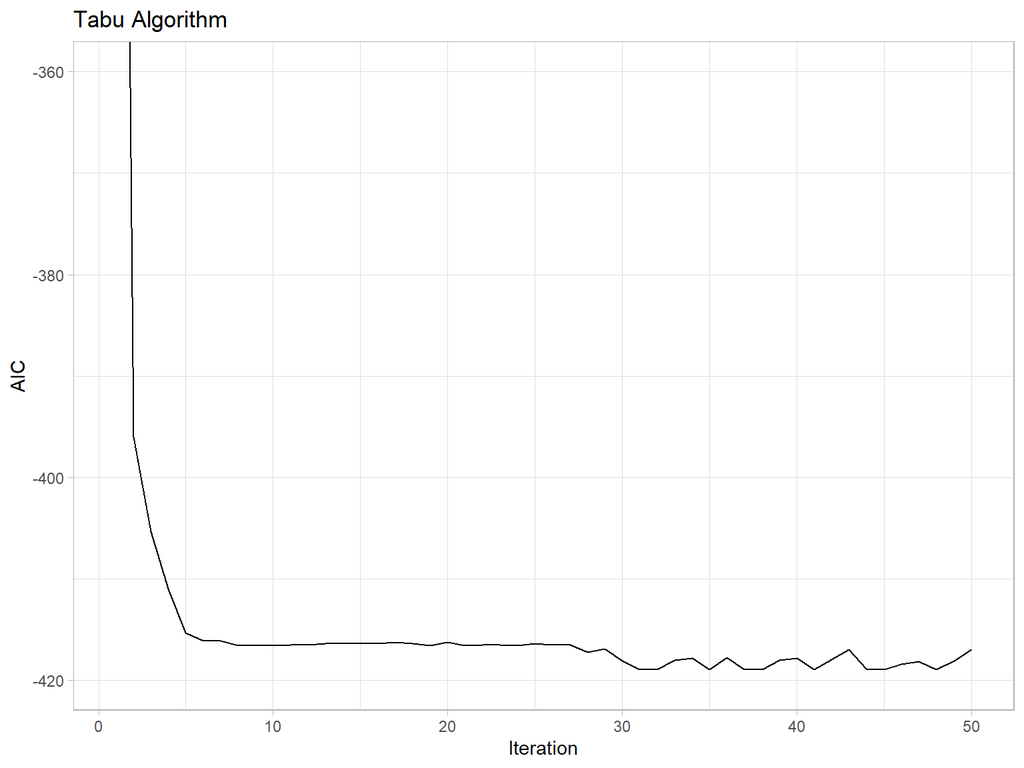

Fig1: Tabu Algorithm without Attribute 4

If the tabu term is **too long**, then good solutions may be skipped.

```r
set.seed(1314)
Tabu_Algorithm(logsalary, data_sub, 10, 50)
```

```
## $method
## [1] "Tabu Algorithm"
##
## $x_best
##  [1] 0 0 1 0 0 1 0 1 0 1 0 0 1 1 0 0 0 0 0 1 1 1 0 1 1 0 0
##
## $aic_best
## [1] -416.6119
##
## $aic
##  [1] -217.0905 -396.0194 -405.3545 -411.0308 -415.3757 -416.1567 -416.1465
##  [8] -416.6030 -416.5411 -416.6119 -416.5543 -416.5411 -416.4249 -416.3035
## [15] -416.3702 -416.2547 -416.4249 -416.1704 -416.3702 -416.4249 -416.1480
## [22] -416.5411 -416.6119 -416.5543 -416.5411 -416.4249 -416.3035 -416.3702
## [29] -416.2547 -416.4249 -416.3702 -416.1704 -416.4249 -416.1480 -416.5411
## [36] -416.6119 -416.5543 -416.5411 -416.4249 -416.3035 -416.3702 -416.4249
## [43] -416.2547 -416.3702 -416.1704 -416.4249 -416.1480 -416.5411 -416.6119
## [50] -416.5543
##
## $tabu_term
## [1] 10
##
## $iter_time
## [1] 50
##
## $graph
```

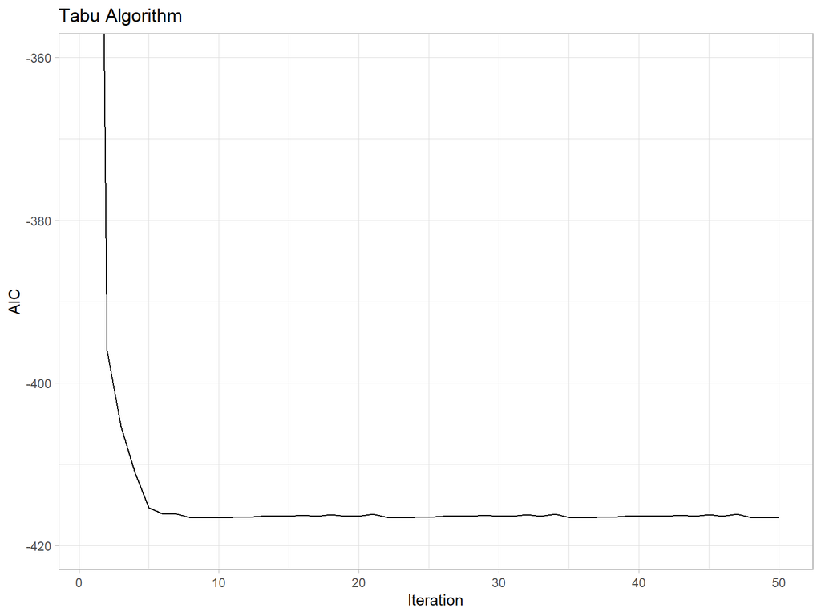

If the tabu term is **too short**, then the algorithm may end up in cycling and cannot skip out of local optimal.

```r
set.seed(1314)
Tabu_Algorithm(logsalary, data_sub, 2, 50)
```

```
## $method
## [1] "Tabu Algorithm"
##
## $x_best
##  [1] 0 0 1 0 0 1 0 1 0 1 0 0 1 1 0 0 0 0 0 1 1 1 0 1 1 0 0
##
## $aic_best
## [1] -416.6119
##
## $aic
##  [1] -217.0905 -396.0194 -405.3545 -411.0308 -415.3757 -416.1567 -416.1465
##  [8] -416.6030 -416.5411 -416.6119 -416.5543 -416.5411 -416.6119 -416.5543
## [15] -416.5411 -416.6119 -416.5543 -416.5411 -416.6119 -416.5543 -416.5411
## [22] -416.6119 -416.5543 -416.5411 -416.6119 -416.5543 -416.5411 -416.6119
## [29] -416.5543 -416.5411 -416.6119 -416.5543 -416.5411 -416.6119 -416.5543
## [36] -416.5411 -416.6119 -416.5543 -416.5411 -416.6119 -416.5543 -416.5411
## [43] -416.6119 -416.5543 -416.5411 -416.6119 -416.5543 -416.5411 -416.6119
## [50] -416.5543
##
## $tabu_term
## [1] 2
##
## $iter_time
## [1] 50
##
## $graph
```

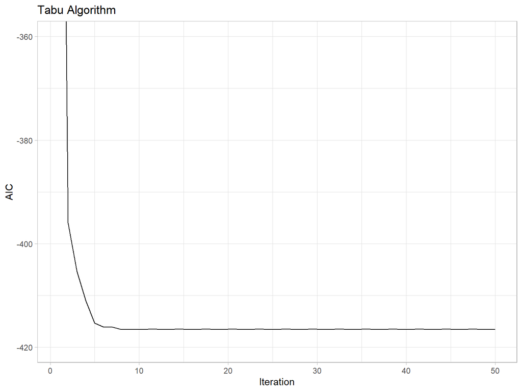

## (b)

Allow Attribute 4 (change in AIC exceeds some value) to be included on the tabu list.

```r
set.seed(1314)
Tabu_Algorithm(logsalary, data_sub, 5, 50, A4 = TRUE)
```

```
## $method
## [1] "Tabu Algorithm"
##
## $x_best
##  [1] 0 1 1 0 0 1 0 1 0 1 0 0 1 1 1 1 0 0 0 0 0 0 0 1 1 1 0
##
## $aic_best
## [1] -418.9472
##
## $aic
##  [1] -217.0905 -396.0194 -405.3545 -411.0308 -415.3757 -416.1567 -416.1465
##  [8] -416.6030 -416.5411 -416.6119 -416.5543 -416.5411 -416.4249 -416.3035
## [15] -416.3702 -416.4249 -416.2547 -416.3702 -416.6030 -416.2717 -416.6119
## [22] -416.5543 -416.5411 -416.6119 -416.4101 -416.5069 -416.5157 -417.2714
## [29] -416.9396 -418.0818 -418.9421 -418.9472 -418.0125 -417.8494 -417.5816
## [36] -418.0125 -417.5184 -418.9472 -418.9421 -418.4511 -418.1540 -418.9421
## [43] -418.0818 -416.9571 -417.3685 -418.0922 -418.9421 -418.9472 -418.0000
## [50] -416.9711
##
## $tabu_term
## [1] 5
##
## $iter_time
## [1] 50
##
## $graph
```

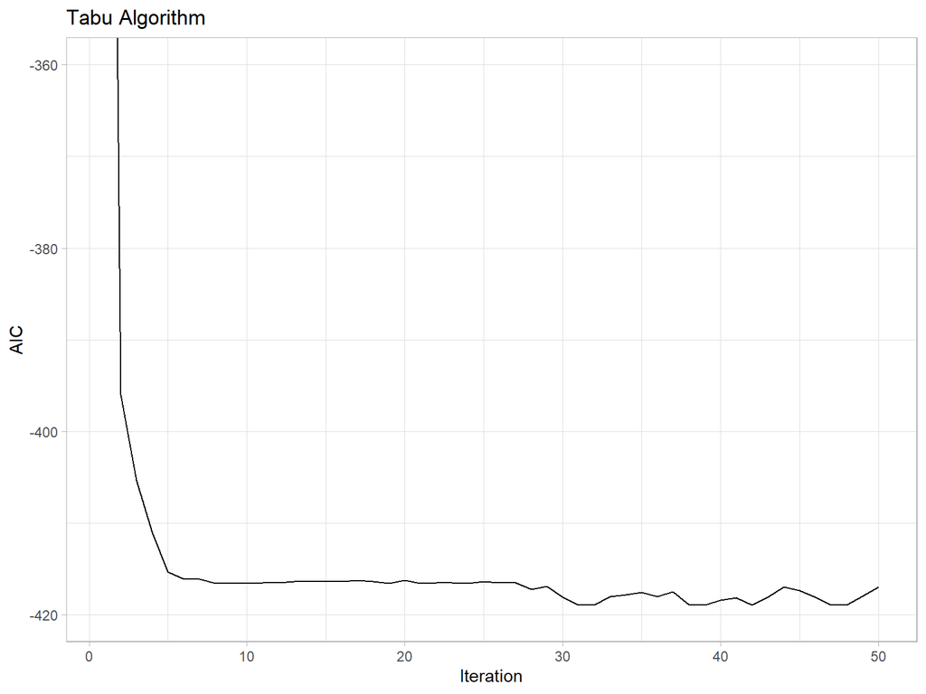

Fig2: Tabu Algorithm with Attribute 4

Compare Fig2 with Fig1. It turns out that if a move with change in AIC greater than A4_value (default is 1) is taken, Attribute 4 can prevent any other drastic changes for a period of time (tabu term), allowing better exploration of the newly entered region of solution space before moving far away. Certainly the search diversity is promoted.

# 3.3

## (b)

Define the `Simulated Annealing` function for combinatorial optimization.

- `y`: dependent variable.
- `vars`: a data frame of all covariates.
- `taustart`: initial temperature.
- `iterstart`: iteration time of the first state.
- `k`: number of changes to the candidate solution.
- `statenum`: number of temperature states.

```r
Simulated_Annealing_C <- function(y, vars, taustart, iterstart, k, statenum){

  ###INITIAL VALUES###
  var_num <- ncol(vars)
  x <- rbinom(var_num, 1, 0.5) ##RANDOM STARTING VALUE
  tau <- taustart
  itertime <- iterstart
  cooling <- seq(iterstart, iterstart + 20 * (statenum - 1), 20) ##ITERATION TIMES AT EACH TEMPERATURE
  aic_list <- c() ##HISTORICAL AIC
  x_list <- matrix(NA, sum(cooling), var_num)
  idx <- 0

  ###FUNCTIONS###
  generate_N1 <- function(x){
    out <- matrix(NA, var_num, var_num)
    for (i in 1:var_num){
      x_temp <- x
      x_temp[i] <- !x[i]
      out[i, ] <- x_temp}
    return (out)
  }
  generate_N2 <- function(x){
    out <- matrix(NA, choose(var_num, 2), var_num)
    idx <- 1
    for (i in 1:(var_num - 1)){
      for (j in (i + 1):var_num){
        x_temp <- x
        x_temp[i] <- !x[i]
        x_temp[j] <- !x[j]
        out[idx, ] <- x_temp
        idx <- idx + 1}}
    return (out)
  }
  generate_N3 <- function(x){
    out <- matrix(NA, choose(var_num, 3), var_num)
    idx <- 1
    for (i in 1:(var_num - 2)){
      for (j in (i + 1):(var_num - 1)){
        for (q in (j + 1):var_num){
          x_temp <- x
          x_temp[i] <- !x[i]
          x_temp[j] <- !x[j]
          x_temp[q] <- !x[q]
          out[idx, ] <- x_temp
          idx <- idx + 1}}}
    return (out)
  }
  ##(K-1) NEIGHBORHOOD IS A SUBSET OF K NEIGHBORHOOD ACCORDING TO 蒋斐宇老师
  generate_N <- function(x, k){
    if (k == 1){return (generate_N1(x))}
    if (k == 2){return (rbind(generate_N1(x), generate_N2(x)))}
    if (k == 3){return (rbind(generate_N1(x), generate_N2(x), generate_N3(x)))}
  }
  generate_AIC <- function(x){
    vars_run <- vars[, x == 1]
    fit <- lm(y ~ ., vars_run)
        return (extractAIC(fit)[2])
  }

  ###MAIN###
  ##ITERATE EACH STATE
  for (i in 1:statenum){

    ##ITERATE AT THE SAME TEMPERATURE
      for (j in 1:itertime){
        aic_start <- generate_AIC(x)
        n <- generate_N(x, k)
        x_run <- n[sample(1:nrow(n), 1), ]
        aic_run <- generate_AIC(x_run)

        ##ACCEPT THE NEW MODEL WITH PROBABILITY P
        p <- min(1, exp((aic_start - aic_run) / tau))
        flag <- rbinom(1, 1, p)
        if (flag == 1){
          x <- x_run
          aic_list <- c(aic_list, aic_run)}
        else {
          if (length(aic_list) == 0){aic_list <- aic_start}
          else {aic_list <- c(aic_list, aic_list[length(aic_list)])}}

        idx <- idx + 1
        x_list[idx, ] <- x
      }

    ##COOLING
    tau <- 0.9 * tau
    itertime <- itertime + 20
  }

  ###OUTPUT###
  structure(list(method = paste(k, '-Neighborhood ', 'Simulated Annealing for combinatorial optimization', sep = ''),
                 iter_best = (1:sum(cooling))[aic_list == min(aic_list)],
                 x_best = x_list[(1:sum(cooling))[aic_list == min(aic_list)][1], ],
                 aic_best = min(aic_list),
                 x = x_list,
                 aic = aic_list,
                 tau_start = taustart,
                 state_num = statenum,
                 iter_time = sum(cooling),
                 cooling = cooling,
                 graph = ggplot() + geom_line(mapping = aes(x = 1:sum(cooling), y = aic_list)) + coord_cartesian(ylim = c(-420, -360)) + labs(title = paste('AIC Curve of ', k, '-Neighborhood ', 'Simulated Annealing for combinatorial optimization', sep = ''), x = 'Iteration', y = 'AIC') + theme_light()))
}
```

Compute results of 2-Neighborhood Simulated Annealing.

```r
set.seed(5201314)
result_N2 <- Simulated_Annealing_C(logsalary, data_sub, 1, 50, 2, 15)
print(paste('BEST LIST OF PREDICTORS FOUND:', paste(result_N2$x_best, collapse = ', '))); print(paste('AIC VALUE:', result_N2$aic_best)); print(paste('NO. OF FIRST BEST ITERATION:', paste(result_N2$iter_best[1], collapse = ', ')))
```

```
## [1] "BEST LIST OF PREDICTORS FOUND: 0, 1, 1, 0, 0, 1, 0, 1, 0, 1, 0, 0, 1, 1, 1, 1, 0, 0, 0, 0, 0, 0, 0, 1, 1, 1, 0"
```

```
## [1] "AIC VALUE: -418.947211437155"
```

```
## [1] "NO. OF FIRST BEST ITERATION: 1055"
```

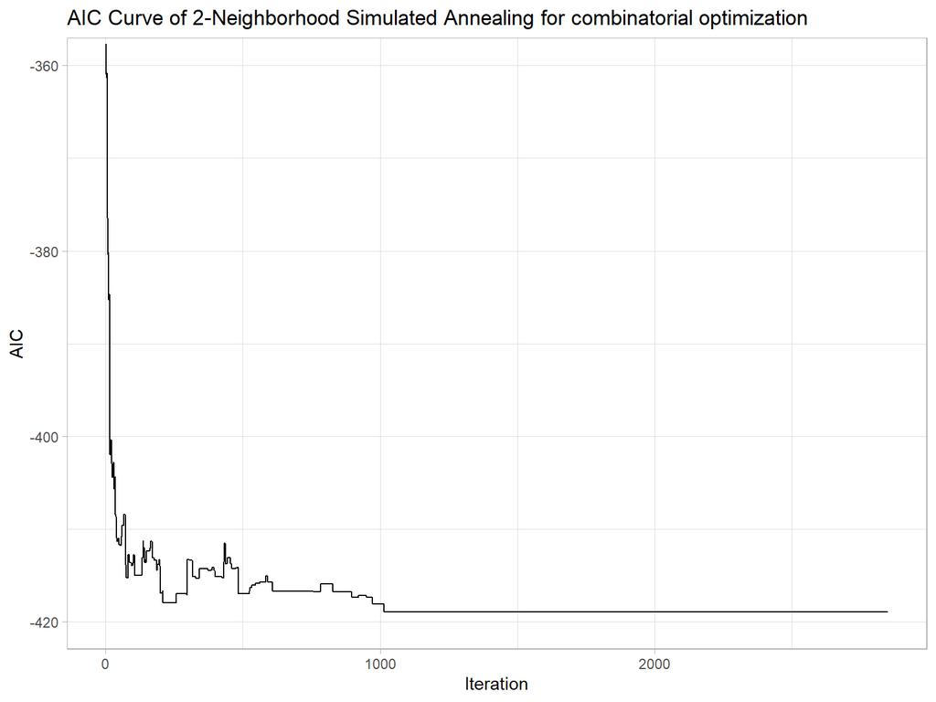

```r
result_N2$graph
```

Compute results of 3-Neighborhood Simulated Annealing.

```r
set.seed(5201314)
result_N3 <- Simulated_Annealing_C(logsalary, data_sub, 1, 50, 3, 18)
print(paste('BEST LIST OF PREDICTORS FOUND:', paste(result_N3$x_best, collapse = ', '))); print(paste('AIC VALUE:', result_N3$aic_best)); print(paste('NO. OF FIRST BEST ITERATION:', paste(result_N3$iter_best[1], collapse = ', ')))
```

```
## [1] "BEST LIST OF PREDICTORS FOUND: 0, 1, 1, 0, 0, 1, 0, 1, 0, 1, 0, 0, 1, 1, 1, 1, 0, 0, 0, 0, 0, 0, 0, 1, 1, 1, 0"
```

```
## [1] "AIC VALUE: -418.947211437155"
```

```
## [1] "NO. OF FIRST BEST ITERATION: 3490"
```

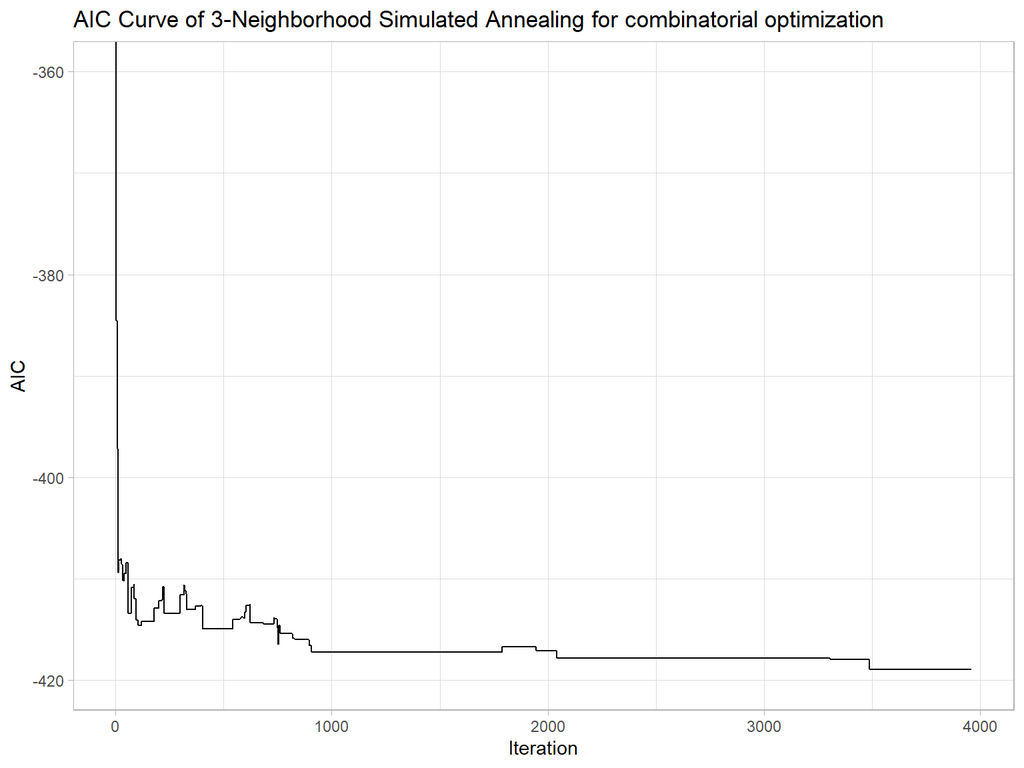

```r
result_N3$graph
```

According to the two AIC curves above, 3-Neighborhood Simulated Annealing needs more iterations than 2-Neighborhood to converge to the lowest AIC.

On condition that the proposal distribution is discrete uniform, the difference between 2-Neighborhood and 3-Neighborhood Simulated Annealing is that in each iteration, the latter’s candidates are far more than the former, so **the probability of choosing a better candidate in 2-Neighborhood is far higher than that in 3-Neighborhood**, which means the latter requires more iterations, cooler temperatures, or both to converge to the global optimal.

# 2.1*

Import the sample points.

```r
X <- c(1.77, -0.23, 2.76, 3.80, 3.47, 56.75, -1.34, 4.24, -2.44, 3.29, 3.71, -2.40, 4.53, -0.07, -1.05, -13.87, -2.53, -1.75, 0.27, 43.21)
```

Define the pdf of $Cauchy(\theta, 1)$.

```r
fx <- function(x, location){1 / pi * (1 / ((x - location) ^ 2 + 1))}
```

Define the log likelihood function. The objective function is `-logL`.

```r
logL <- function(theta){sum(log(fx(X, theta)))}
```

Define the `Simulated Annealing` function for numerical optimization.

- `xstart`: starting value.
- `taustart`: initial temperature.
- `iterstart`: iteration time of the first state.
- `statenum`: number of temperature states.
- `method`: proposal density function to use, e.g. ‘normal’, ‘cauchy’.

The following algorithm provides two alternatives of proposal density function.

- Normal Distribution $N(x^{(t)},\tau^{(k)})$.
  $$g^{(t)}(·|x^{(t)})=(2\pi\tau^{(k)})^{-\frac 1 2}exp\{-\frac
  {(x-x^{(t)})^2} {2\tau^{(k)}}\}$$
- Cauchy Distribution $Cauchy(x^{(t)},\tau^{(k)})$.
  $$g^{(t)}(·|x^{(t)})={\frac 1\pi} * {\frac {\tau^{(k)}} {(x - x^{(t)}) ^ 2
  + ({\tau^{(k)}}) ^ 2}}$$

$x^{(t)}$ is the current $x$. $\tau^{(k)}$ is the temperature of $k^{th}$ stage.

The neighborhood of $x^{(t)}$ can be regarded as the whole set of real numbers. Both of the proposal density functions follow unimodal distribution. The probability of selecting a nearby neighbor will increase as temperature $\tau^{(k)}$ goes down, which means $x^*$ becomes less likely to jump to a distant neighbor. This performance is consistent with the key idea of Simulated Annealing, so both functions are suitable for the algorithms.

The main difference of the two methods is that Cauchy distribution is a fat-tailed distribution, indicating that a distant neighbor is more likely to be selected as the candidate than Normal distribution. As a result, Simulated Annealing with Cauchy may be better at skipping out of the local optimal.

```r
Simulated_Annealing_N <- function(xstart, taustart, iterstart, statenum, method){

  ###INITIAL VALUES###
  x <- xstart
  tau <- taustart
  itertime <- iterstart
  cooling <- seq(iterstart, iterstart + 20 * (statenum - 1), 20)
  logL_list <- c()
  x_list <- c()

  ###FUNCTIONS###
  generate_x <- function(x){
    if (method == 'normal'){out <- rnorm(1, x, sqrt(tau))}
    if (method == 'cauchy'){out <- rcauchy(1, x, tau)}
    return (out)
  }

  ###MAIN###
  ##ITERATE EACH STATE
  for (i in 1:statenum){

    ##ITERATE AT THE SAME TEMPERATURE
      for (j in 1:itertime){
        logL_start <- - logL(x)
        x_run <- generate_x(x)
        logL_run <- - logL(x_run)

        ##ACCEPT THE NEW MODEL WITH PROBABILITY P
        p <- min(1, exp((logL_start - logL_run) / tau))
        flag <- rbinom(1, 1, p)
        if (flag == 1){
          x <- x_run
          logL_list <- c(logL_list, logL_run)}
        else {
          if (length(logL_list) == 0){logL_list <- logL_start}
          else {logL_list <- c(logL_list, logL_list[length(logL_list)])}}

        x_list <- c(x_list, x)
      }

    ##COOLING
    tau <- 0.9 * tau
    itertime <- itertime + 20
  }

  ###OUTPUT###
  structure(list(method = paste('Simulated Annealing for numerical optimization (', method, ')', sep = ''),
                 iter_best = (1:sum(cooling))[logL_list == min(logL_list)],
                 x_best = x_list[(1:sum(cooling))[logL_list == min(logL_list)][1]],
                 logL_best = - min(logL_list),
                 x = x_list,
                 logL = - logL_list,
                 tau_start = taustart,
                 state_num = statenum,
                 iter_time = sum(cooling),
                 cooling = cooling,
                 graph = ggplot() + geom_line(mapping = aes(x = 1:sum(cooling), y = - logL_list)) + coord_cartesian(ylim = c(-73.3, -72.9)) + labs(title = paste('Simulated Annealing for numerical optimization (', method, ')', sep = ''), x = 'Iteration', y = 'logL') + theme_light()))
}
```

Compute results with normal proposal density function.

```r
set.seed(5201314)
result_n <- Simulated_Annealing_N(-1, 0.02, 50, 20, 'normal')
print(paste('BEST THETA:', paste(result_n$x_best, collapse = ', '))); print(paste('LOG LIKELIHOOD VALUE:', result_n$logL_best)); print(paste('NO. OF FIRST BEST ITERATION:', paste(result_n$iter_best[1], collapse = ', ')))
```

```
## [1] "BEST THETA: -0.192295979698978"
```

```
## [1] "LOG LIKELIHOOD VALUE: -72.9158196159813"
```

```
## [1] "NO. OF FIRST BEST ITERATION: 2002"
```

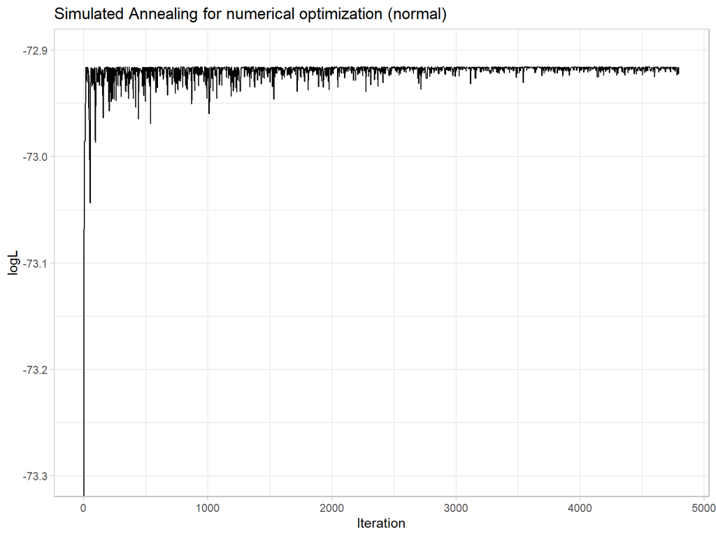

```r
result_n$graph
```

Compute results with cauchy proposal density function.

```r
set.seed(5201314)
result_c <- Simulated_Annealing_N(-1, 0.02, 50, 20, 'cauchy')
print(paste('BEST THETA:', paste(result_c$x_best, collapse = ', '))); print(paste('LOG LIKELIHOOD VALUE:', result_c$logL_best)); print(paste('NO. OF FIRST BEST ITERATION:', paste(result_c$iter_best[1], collapse = ', ')))
```

```
## [1] "BEST THETA: -0.192290736686951"
```

```
## [1] "LOG LIKELIHOOD VALUE: -72.9158196158723"
```

```
## [1] "NO. OF FIRST BEST ITERATION: 2025"
```

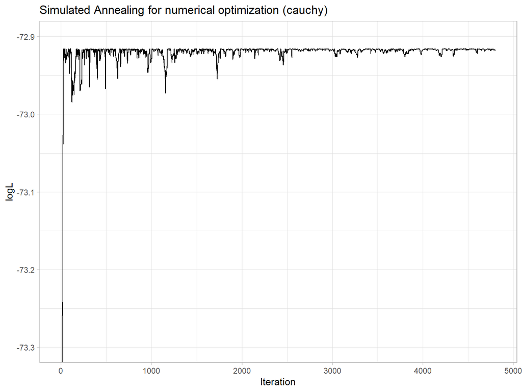

```r
result_c$graph
```

# 3.6

## (a)

Load and preview data `geneticmapping.dat`.

```r
data <- read.table('geneticmapping.dat', header = TRUE)
DT::datatable(data)
```

|  | loc1 | loc2 | loc3 | loc4 | loc5 | loc6 | loc7 | loc8 | loc9 | loc10 | loc11 | loc12 |
| --- | --- | --- | --- | --- | --- | --- | --- | --- | --- | --- | --- | --- |
| 1 | 1 | 0 | 1 | 0 | 0 | 1 | 1 | 0 | 0 | 1 | 0 | 0 |
| 2 | 1 | 1 | 1 | 1 | 1 | 1 | 1 | 1 | 1 | 1 | 1 | 1 |
| 3 | 1 | 1 | 1 | 1 | 1 | 1 | 1 | 1 | 0 | 1 | 0 | 1 |
| 4 | 1 | 1 | 1 | 1 | 1 | 1 | 1 | 1 | 1 | 0 | 1 | 1 |
| 5 | 1 | 1 | 0 | 1 | 1 | 0 | 0 | 1 | 1 | 1 | 1 | 1 |
| 6 | 0 | 1 | 0 | 1 | 0 | 0 | 0 | 0 | 0 | 0 | 0 | 1 |
| 7 | 0 | 0 | 0 | 0 | 0 | 0 | 0 | 0 | 0 | 0 | 0 | 0 |
| 8 | 1 | 1 | 0 | 1 | 1 | 1 | 1 | 1 | 1 | 1 | 1 | 1 |
| 9 | 0 | 1 | 1 | 1 | 0 | 1 | 1 | 0 | 0 | 0 | 0 | 1 |
| 10 | 0 | 0 | 0 | 0 | 1 | 0 | 0 | 1 | 0 | 1 | 0 | 0 |

[output cut: 86 more lines]

Define the `Genetic Algorithm` function.

- `df`: genetic mapping data.
- `P`: size of each generation.
- `m`: mutation rate.
- `itertime`: number of generations to run.
- `method`: crossover operator to use, e.g. ‘order’, ‘edge’.
- `k`: number of loci selected to be order crossovered.

```r
Genetic_Algorithm <- function(df, P, m, itertime, method, k = NULL){

  ###FUNCTIONS###
  ##DISTANCE
  d_hat <- function(theta1, theta2){
    out <- 1 / n * sum(abs(df[, theta1] - df[, theta2]))
    return (out)
  }
  ##T
  generate_T <- function(theta1, theta2){
    if (d_hat(theta1, theta2) == 0 | d_hat(theta1, theta2) == 1){out <- 0}
    else {out <- n * (d_hat(theta1, theta2) * log(d_hat(theta1, theta2)) + (1 - d_hat(theta1, theta2)) * log(1 - d_hat(theta1, theta2)))}
    return (out)
  }
  ##PROFILE LOG LIKELIHOOD
  plog_L <- function(theta){
    out <- c()
    for (a in 1:P){
      l <- 0
      for (b in 1:(c - 1)){l <- l + T_matrix[theta[a, b], theta[a, b + 1]]}
      out <- c(out, l)
    }
    return (out)
  }
  ##FITNESS: RANK SPECIFICATION
  fitness <- function(l){
    phi <- 2 * rank(l) / (P * (P + 1))
    return (phi)
  }
  ##ORDER CROSSOVER
  order_crossover <- function(theta1, theta2){
    idx_cross <- sample(1:c, k)
    ord1 <- c(); ord2 <- c()
    for (a in 1:k){
      ord1 <- c(ord1, which(theta1 == idx_cross[a]))
      ord2 <- c(ord2, which(theta2 == idx_cross[a]))
    }
    ord1 <- ord1[order(ord1)]; ord2 <- ord2[order(ord2)]
    out <- theta2
    for (a in 1:k){out[ord2[a]] <- theta1[ord1[a]]}
    return (out)
  }
  ##EDGE-RECOMBINATION CROSSOVER
  edge_crossover <- function(theta1, theta2){
    ##GENERATE EDGE TABLE
    edge_table <- rep(list(NA), c)
    idx1 <- order(theta1); idx2 <- order(theta2)
    for (a in 1:c){
      if (idx1[a] == 1){link1 <- c(theta1[2], theta1[c])}
      else if (idx1[a] == c){link1 <- c(theta1[1], theta1[c - 1])}
      else {link1 <- c(theta1[idx1[a] - 1], theta1[idx1[a] + 1])}
      if (idx2[a] == 1){link2 <- c(theta2[2], theta2[c])}
      else if (idx2[a] == c){link2 <- c(theta2[1], theta2[c - 1])}
      else {link2 <- c(theta2[idx2[a] - 1], theta2[idx2[a] + 1])}
      edge_table[[a]] <- c(na.omit(unique(c(link1, link2))))
    }
    ##CHOOSE THE STARTING POINT
    if (length(edge_table[[theta1[1]]]) < length(edge_table[[theta2[1]]])){out <- theta1[1]}
    else {out <- theta2[1]}
    ##ITERATION
    for (a in 2:(c - 1)){
      last_point <- out[length(out)]
      idx <- edge_table[[last_point]]
      ##DELETE LAST POINT
      len <- c()
      for (b in 1:length(idx)){
        edge_table[[idx[b]]] = edge_table[[idx[b]]][which(edge_table[[idx[b]]]!=last_point)]
        len_temp <- length(edge_table[[idx[b]]])
        ##SOMETIMES LINK WILL BREAK, CHOOSE NEW PARENTS TO CROSS OVER
        if (len_temp == 0){return(NULL)}
        len <- c(len, len_temp)
      }
      out <- c(out, idx[which.min(len)[1]])
    }
    out <- c(out, setdiff(1:c, out))
    return (out)
  }

  ###INITIAL VALUES###
  n <- nrow(df)
  c <- ncol(df)
  ##STARTING VALUES OF THETA
  theta <- matrix(NA, P, c)
  for (i in 1:P){theta[i, ] <- sample(1:c, c)}
  ##CALCULATE THE T MATRIX
  T_matrix <- matrix(NA, c, c)
  for (i in 1:c){
    for (j in 1:c){T_matrix[i, j] <- generate_T(i, j)}}
  ##STARTING VALUES OF PROFILE LOGLIKELIHOOD
  l <- plog_L(theta)
  l_best <- max(l)
  theta_best <- theta[which.max(l), ]
  l_list <- data.frame('iteration' = 0, 'plogL' = l)

  ###MAIN###
  for (i in 1:itertime){

    ##SELECTION
    idx_select <- sample(1:P, P, replace = TRUE, prob = fitness(l))
    theta_select <- theta
    for (j in 1:P){theta_select[j, ] <- theta[idx_select[j], ]}

    ##ORDER CROSSOVER
    if (method == 'order'){
      theta_cross <- theta_select
      for (q in seq(1, P - 1, 2)){
        theta_cross[q, ] <- order_crossover(theta_select[q, ], theta_select[q + 1, ])
        theta_cross[q + 1, ] <- order_crossover(theta_select[q + 1, ], theta_select[q, ])
      }
    }

    ##EDGE-RECOMBINATION CROSSOVER
    if (method == 'edge'){
      theta_cross <- theta_select
      for (q in 1:(P - 1)){
        theta_new <- edge_crossover(theta_select[q, ], theta_select[q + 1, ])
        while (length(theta_new) != 12){theta_new <- edge_crossover(theta_select[sample(1:P, 1), ], theta_select[sample(1:P, 1), ])}
        theta_cross[q, ] <- theta_new
      }
      theta_new <- edge_crossover(theta_select[P, ], theta_select[1, ])
      while (length(theta_new) != 12){theta_new <- edge_crossover(theta_select[sample(1:P, 1), ], theta_select[sample(1:P, 1), ])}
      theta_cross[P, ] <- theta_new
    }

    ##MUTATION: CHOOSE LOCUS AT MUTATION RATE TO EXCHANGE THE ORDER WITH ANOTHER LOCUS ON THE SAME CHROMOSOME.
    theta_mutate <- theta_cross
    idx_mutate <- rbinom(P * c, 1, m)
    if (1 %in% idx_mutate){
      for (j in which(idx_mutate == 1)){
        theta_cross <- theta_mutate
        if (j %% P != 0){
          idx_r <- j %% P
          idx_c <- j %/% P + 1
        }
        else {
          idx_r <- P
          idx_c <- j %/% P
        }
        idx <- sample(seq(1, c)[-which(1:c==idx_c)], 1)
        theta_mutate[idx_r, idx_c] <- theta_cross[idx_r, idx]
        theta_mutate[idx_r, idx] <- theta_cross[idx_r, idx_c]
      }
    }
    theta <- theta_mutate
    l <- plog_L(theta)
    l_list <- rbind(l_list, data.frame('iteration' = i, 'plogL' = l))
    if (max(l) > l_best){l_best <- max(l); theta_best <- theta[which.max(l), ]}
  }

  ###OUTPUT###
  structure(list(method = paste('Genetic Algorithm (', ifelse(method=='order', 'order', 'edge-recombination'), ' crossover)', sep = ''),
                 iter_best = l_list[which.max(l_list$plogL)[1], 1],
                 theta_best = theta_best,
                 plogL_best = l_best,
                 P = P,
                 mutationrate = m,
                 iter_time = itertime,
                 graph = ggplot() + geom_point(mapping = aes(x = l_list$iteration, y = l_list$plogL), alpha = 0.5) + coord_cartesian(ylim = c(-650, -290)) + labs(title = paste('Genetic Algorithm (', ifelse(method=='order', 'order', 'edge-recombination'), ' crossover)', sep = ''), x = 'Iteration', y = 'plogL') + theme_light()))
}
```

Compute results.

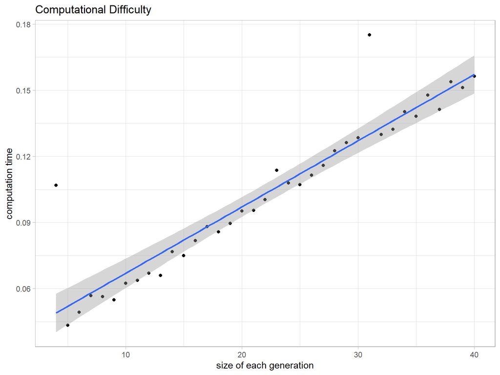

```r
set.seed(1314)
t <- c()
result_p <- c()
for (p in 4:40){
  start <- Sys.time()
  result_p = c(result_p, Genetic_Algorithm(data, p, 0.01, 100, 'order', 3)$plogL_best)
  end <- Sys.time()
  t <- c(t, end - start)
}
ggplot(mapping = aes(x = 4:40, y = t)) + geom_point() + geom_smooth(method = 'lm') + labs(title = 'Computational Difficulty', x = 'size of each generation', y = 'computation time') + theme_light()
```

Given iteration times = 100, mutation rate = 1%, test the 3-order-crossover(selecting 3 loci to cross over) algorithm with P ranging from 4 to 40. It turns out that the computational difficulty is O(p), which means that this problem can be solved in polynomial time.

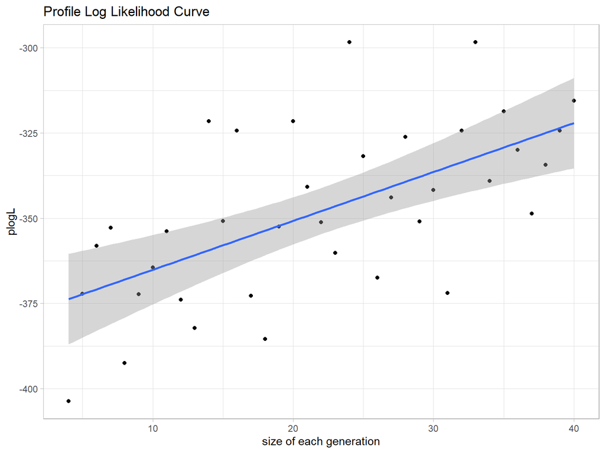

```r
ggplot(mapping = aes(x = 4:40, y = result_p)) + geom_point() + geom_smooth(method = 'lm') + labs(title = 'Profile Log Likelihood Curve', x = 'size of each generation', y = 'plogL') + theme_light()
```

The performance with given parameters is not very good because only a few of them converge to the global optimal. Nevertheless, the graph above shows a trend that the ending plogL may increase with the size of generation, indicating that increasing P may be a good way to improve the algorithm. Besides, we can also increase the iteration times, change the mutation rate (or even change the random seed, etc.) to help the algorithm find the global optimal.

Choose P=20, mutation rate=0.01, iteration times=100 as the parameter of algorithm baseline (just an example to prove the aforementioned methods make sense). It doesn’t converge to the global optimal.

```r
set.seed(1314)
Genetic_Algorithm(data, 20, 0.01, 100, 'order', 3)
```

```
## $method
## [1] "Genetic Algorithm (order crossover)"
##
## $iter_best
## [1] 78
##
## $theta_best
##  [1]  2  4 12  7  3  6  1 11  9  8  5 10
##
## $plogL_best
## [1] -314.6324
##
## $P
## [1] 20
##
## $mutationrate
## [1] 0.01
##
## $iter_time
## [1] 100
##
## $graph
```

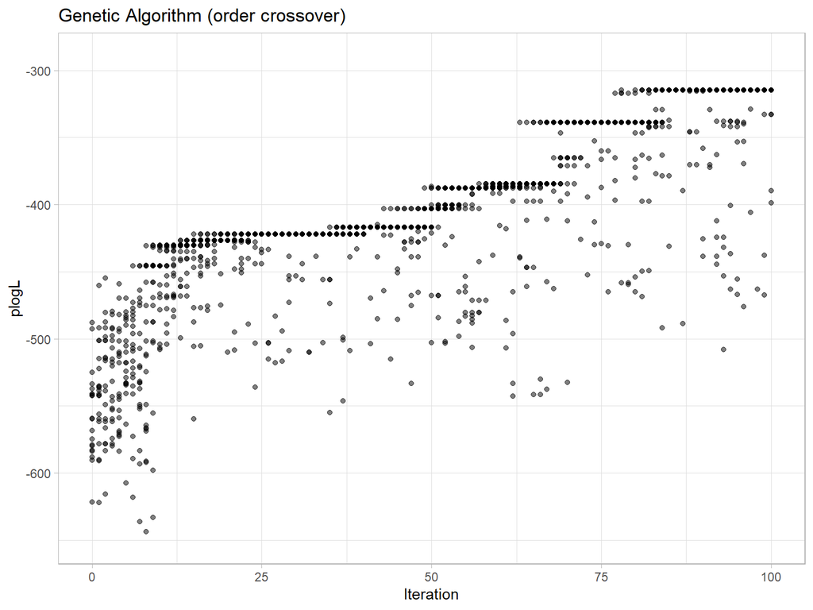

- Increase the size of each generation (to 30). This can discourage premature convergence and promote search diversity. But P shouldn’t be too large, or the algorithm may be too slow to use.

```r
set.seed(1314)
Genetic_Algorithm(data, 30, 0.01, 100, 'order', 3)
```

```
## $method
## [1] "Genetic Algorithm (order crossover)"
##
## $iter_best
## [1] 39
##
## $theta_best
##  [1] 10  5  8  9 11  1  7  3  6 12  4  2
##
## $plogL_best
## [1] -298.3949
##
## $P
## [1] 30
##
## $mutationrate
## [1] 0.01
##
## $iter_time
## [1] 100
##
## $graph
```

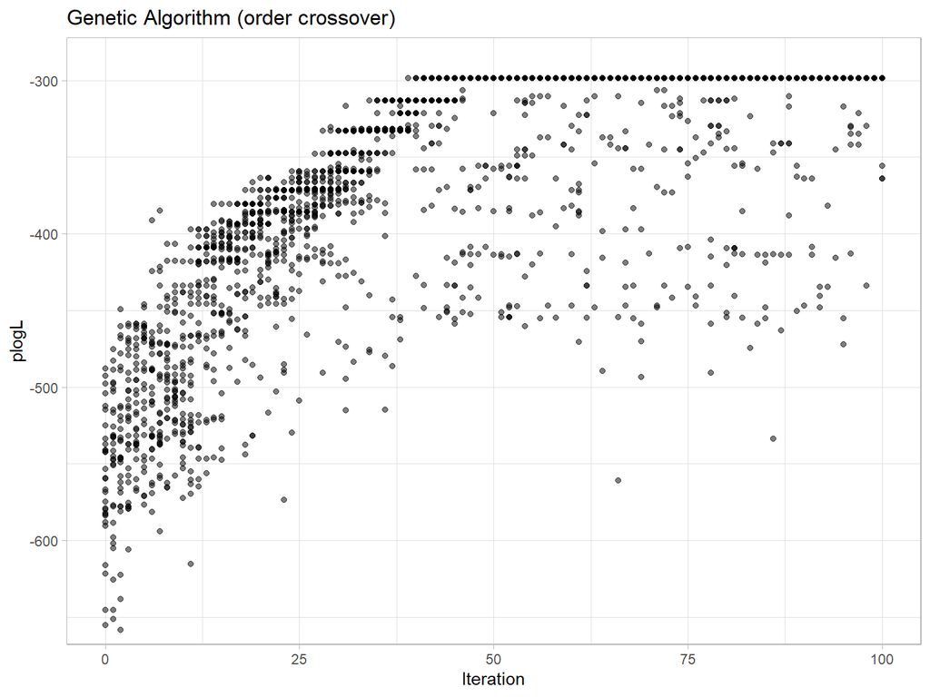

- Increase the iteration times (to 500). More chances are that the algorithm finds the desirable schemata.

```r
set.seed(1314)
Genetic_Algorithm(data, 20, 0.01, 500, 'order', 3)
```

```
## $method
## [1] "Genetic Algorithm (order crossover)"
##
## $iter_best
## [1] 103
##
## $theta_best
##  [1]  2  4 12  6  3  7  1 11  9  8  5 10
##
## $plogL_best
## [1] -298.3949
##
## $P
## [1] 20
##
## $mutationrate
## [1] 0.01
##
## $iter_time
## [1] 500
##
## $graph
```

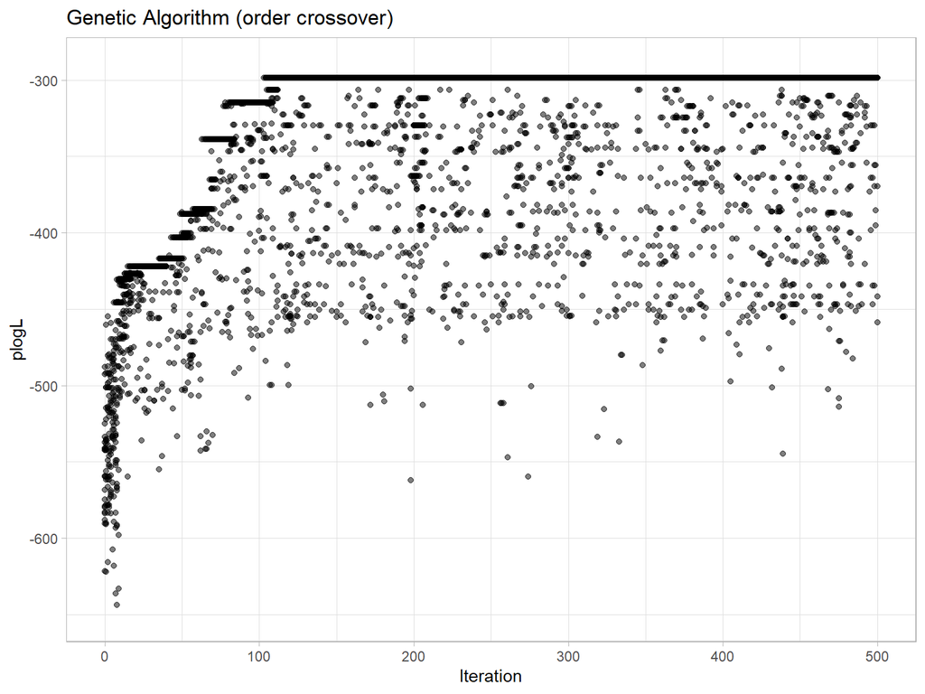

- Change the mutation rate (to 0.015). The mutation rate shouldn’t be too low, or many potentially good innovations will be missed. It shouldn’t be too high as well, or the algorithm’s ability to learn over time will be degraded because excessive random variation will disturb the fitness selectivity of parents and the inheritance of desirable schemata.

```r
set.seed(1314)
Genetic_Algorithm(data, 20, 0.015, 100, 'order', 3)
```

```
## $method
## [1] "Genetic Algorithm (order crossover)"
##
## $iter_best
## [1] 96
##
## $theta_best
##  [1]  2  4 12  6  3  7  1 11  9  8  5 10
##
## $plogL_best
## [1] -298.3949
##
## $P
## [1] 20
##
## $mutationrate
## [1] 0.015
##
## $iter_time
## [1] 100
##
## $graph
```

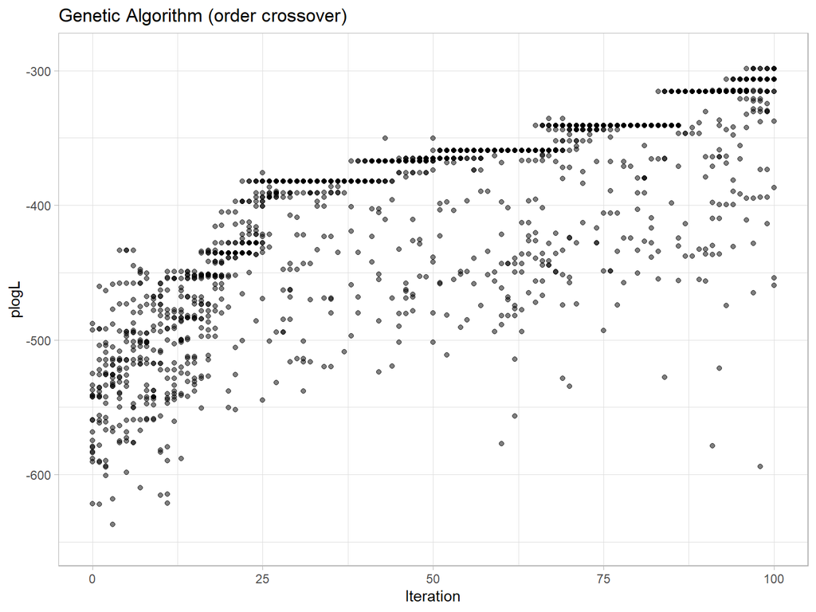

- Change the random seed. Good luck.

```r
set.seed(2023)
Genetic_Algorithm(data, 20, 0.01, 100, 'order', 3)
```

```
## $method
## [1] "Genetic Algorithm (order crossover)"
##
## $iter_best
## [1] 57
##
## $theta_best
##  [1]  2  4 12  6  3  7  1 11  9  8  5 10
##
## $plogL_best
## [1] -298.3949
##
## $P
## [1] 20
##
## $mutationrate
## [1] 0.01
##
## $iter_time
## [1] 100
##
## $graph
```

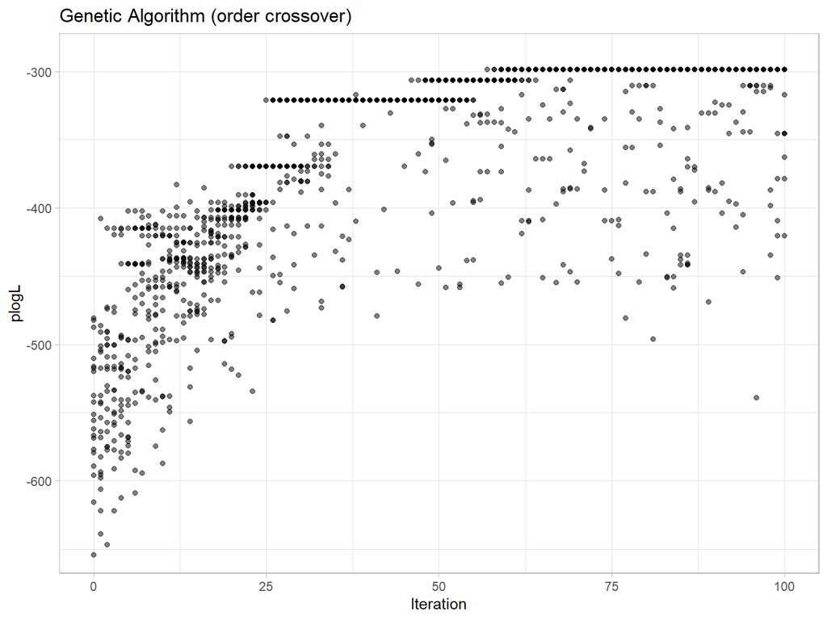

As we can see, all the measures above can somehow improve the algorithm and help it converge to global optimal and converge faster. Certainly there are many other methods to improve search, but only a few simple common methods are selected here because I think they can show my opinion well enough.

## (b)

Compare the order crossover and the edge-recombination crossover strategy.

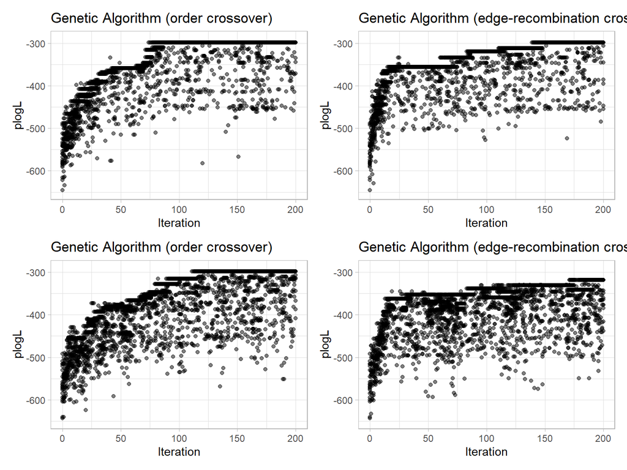

```r
set.seed(1314)
p1 <- Genetic_Algorithm(data, 25, 0.01, 200, 'order', 2)$graph
set.seed(1314)
p2 <- Genetic_Algorithm(data, 25, 0.01, 200, 'edge')$graph
set.seed(520)
p3 <- Genetic_Algorithm(data, 20, 0.02, 200, 'order', 3)$graph
set.seed(520)
p4 <- Genetic_Algorithm(data, 20, 0.02, 200, 'edge')$graph
p1 + p2 + p3 + p4
```

Compare the speed of fitness improvements by observing the **first 50 iterations**. It seems that edge-recombination crossover is faster than order crossover. I guess it is because order crossover may break the links between loci in parents and unintentionally create mutation which may disturb the fitness selectivity of parents and the inheritance of desirable schemata, while edge-recombination crossover is proposed to produce offspring that contain only links present in at least one parent.